# Prediction Assignment Writeup

Rajesh Solanki

October 4, 2018

## Background

Using devices such as Jawbone Up, Nike FuelBand, and Fitbit it is now possible to collect a large amount of data about personal activity relatively inexpensively. These type of devices are part of the quantified self movement - a group of enthusiasts who take measurements about themselves regularly to improve their health, to find patterns in their behavior, or because they are tech geeks. One thing that people regularly do is quantify how much of a particular activity they do, but they rarely quantify how well they do it. In this project, your goal will be to use data from accelerometers on the belt, forearm, arm, and dumbell of 6 participants. They were asked to perform barbell lifts correctly and incorrectly in 5 different ways. More information is available from the website here: http://web.archive.org/web/20161224072740/http:/groupware.les.inf.puc-rio.br/har (see the section on the Weight Lifting Exercise Dataset).

## Data

The training data for this project are available here: https://d396qusza40orc.cloudfront.net/predmachlearn/pml-training.csv The test data are available here: https://d396qusza40orc.cloudfront.net/predmachlearn/pml-testing.csv

The data for this project come from this source: http://web.archive.org/web/20161224072740/http:/groupware.les.inf.puc-rio.br/har. If you use the document you create for this class for any purpose please cite them as they have been very generous in allowing their data to be used for this kind of assignment.

## Pre-Processing

This segment include uploading data from website and loading required pacages..

```r
library(caret); library(rpart);library(ggplot2);library(randomForest)
### Download Data
trainURL <- "https://d396qusza40orc.cloudfront.net/predmachlearn/pml-training.csv"
testURL <- "https://d396qusza40orc.cloudfront.net/predmachlearn/pml-testing.csv"
training <- read.csv(url(trainURL), na.strings = c("NA","#DIV/0!",""))
testing <- read.csv(url(testURL), na.strings = c("NA","#DIV/0!",""))

# Data Cleaning
training<- training[, colSums(is.na(training)) == 0]
testing <- testing[, colSums(is.na(testing)) == 0]

head(colnames(training))
```

```
## [1] "X"                    "user_name"            "raw_timestamp_part_1"
## [4] "raw_timestamp_part_2" "cvtd_timestamp"       "new_window"
```

```r
### The first 7 variables of the training data were deleted, because they are irrelevant to the prediction.
training <- training[,8:dim(training)[2]]
testing <- testing[,8:dim(testing)[2]]
```

## Training, Testing & Validation Data

The training dataset was separated into three parts: tranining part (60%), testing part (20%), and validation part (20%)

```r
set.seed(123)
trainingdata1 <- createDataPartition(y = training$classe, p = 0.8, list = F)
trainingdata2 <- training[trainingdata1,]
validation <- training[-trainingdata1,]
modelingdata <- createDataPartition(y = trainingdata2$classe, p = 0.75, list = F)
modeltraining <- trainingdata2[modelingdata,]
modeltesting <- trainingdata2[-modelingdata,]
```

## Data exploration

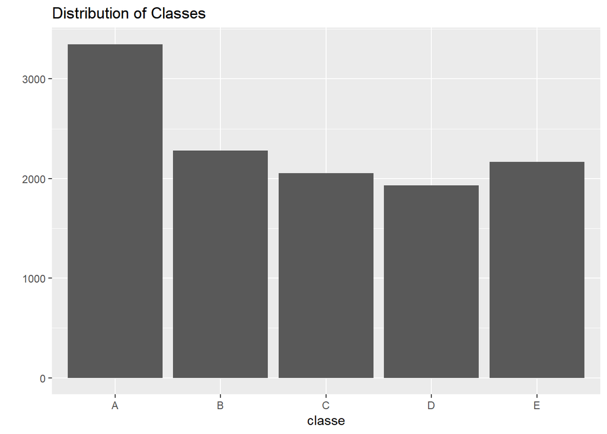

```r
qplot(classe, data=modeltraining, main="Distribution of Classes")
```

```r
names(modeltraining)
```

```
##  [1] "roll_belt"            "pitch_belt"           "yaw_belt"
##  [4] "total_accel_belt"     "gyros_belt_x"         "gyros_belt_y"
##  [7] "gyros_belt_z"         "accel_belt_x"         "accel_belt_y"
## [10] "accel_belt_z"         "magnet_belt_x"        "magnet_belt_y"
## [13] "magnet_belt_z"        "roll_arm"             "pitch_arm"
## [16] "yaw_arm"              "total_accel_arm"      "gyros_arm_x"
## [19] "gyros_arm_y"          "gyros_arm_z"          "accel_arm_x"
## [22] "accel_arm_y"          "accel_arm_z"          "magnet_arm_x"
## [25] "magnet_arm_y"         "magnet_arm_z"         "roll_dumbbell"
## [28] "pitch_dumbbell"       "yaw_dumbbell"         "total_accel_dumbbell"
## [31] "gyros_dumbbell_x"     "gyros_dumbbell_y"     "gyros_dumbbell_z"
## [34] "accel_dumbbell_x"     "accel_dumbbell_y"     "accel_dumbbell_z"
## [37] "magnet_dumbbell_x"    "magnet_dumbbell_y"    "magnet_dumbbell_z"
## [40] "roll_forearm"         "pitch_forearm"        "yaw_forearm"
## [43] "total_accel_forearm"  "gyros_forearm_x"      "gyros_forearm_y"
## [46] "gyros_forearm_z"      "accel_forearm_x"      "accel_forearm_y"
## [49] "accel_forearm_z"      "magnet_forearm_x"     "magnet_forearm_y"
## [52] "magnet_forearm_z"     "classe"
```

## Model-1 : Classification Tree

```r
model_tree <- rpart(classe ~ ., data=modeltraining, method="class")
prediction_tree <- predict(model_tree, modeltesting, type="class")
class_tree <- confusionMatrix(prediction_tree, modeltesting$classe)
class_tree
```

```
## Confusion Matrix and Statistics
##
##           Reference
## Prediction   A   B   C   D   E
##          A 944 111   7  53  42
##          B  53 492  51  59  53
##          C  49  98 447  54  51
##          D  47  33 178 468  70
##          E  23  25   1   9 505
##
## Overall Statistics
##
##                Accuracy : 0.728
##                  95% CI : (0.7138, 0.7419)
##     No Information Rate : 0.2845
##     P-Value [Acc > NIR] : < 2.2e-16
##
##                   Kappa : 0.6559
##  Mcnemar's Test P-Value : < 2.2e-16
##
## Statistics by Class:
##
##                      Class: A Class: B Class: C Class: D Class: E
## Sensitivity            0.8459   0.6482   0.6535   0.7278   0.7004
## Specificity            0.9241   0.9317   0.9222   0.9000   0.9819
## Pos Pred Value         0.8159   0.6949   0.6395   0.5879   0.8970
## Neg Pred Value         0.9378   0.9170   0.9265   0.9440   0.9357
## Prevalence             0.2845   0.1935   0.1744   0.1639   0.1838
## Detection Rate         0.2406   0.1254   0.1139   0.1193   0.1287
## Detection Prevalence   0.2949   0.1805   0.1782   0.2029   0.1435
## Balanced Accuracy      0.8850   0.7900   0.7879   0.8139   0.8412
```

#### Ploting model tree

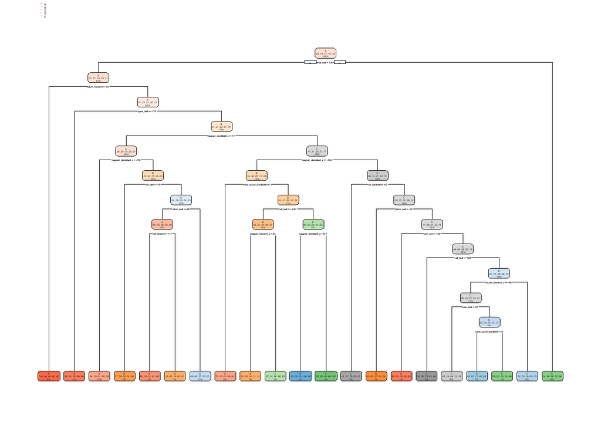

```r
library(rpart.plot)
rpart.plot(model_tree)
```

## Model-2 : Random Forest Model

```r
forest_model <- randomForest(classe ~ ., data=modeltraining, method="class")
prediction_forest <- predict(forest_model, modeltesting, type="class")
random_forest <- confusionMatrix(prediction_forest, modeltesting$classe)
random_forest
```

```
## Confusion Matrix and Statistics
##
##           Reference
## Prediction    A    B    C    D    E
##          A 1116    2    0    0    0
##          B    0  753    5    0    0
##          C    0    3  678    9    0
##          D    0    1    1  634    1
##          E    0    0    0    0  720
##
## Overall Statistics
##
##                Accuracy : 0.9944
##                  95% CI : (0.9915, 0.9965)
##     No Information Rate : 0.2845
##     P-Value [Acc > NIR] : < 2.2e-16
##
##                   Kappa : 0.9929
##  Mcnemar's Test P-Value : NA
##
## Statistics by Class:
##
##                      Class: A Class: B Class: C Class: D Class: E
## Sensitivity            1.0000   0.9921   0.9912   0.9860   0.9986
## Specificity            0.9993   0.9984   0.9963   0.9991   1.0000
## Pos Pred Value         0.9982   0.9934   0.9826   0.9953   1.0000
## Neg Pred Value         1.0000   0.9981   0.9981   0.9973   0.9997
## Prevalence             0.2845   0.1935   0.1744   0.1639   0.1838
## Detection Rate         0.2845   0.1919   0.1728   0.1616   0.1835
## Detection Prevalence   0.2850   0.1932   0.1759   0.1624   0.1835
## Balanced Accuracy      0.9996   0.9953   0.9938   0.9925   0.9993
```

## Model-3 : Liner Discriminant Analysis

```r
lda_model <- train(classe ~ ., data=modeltraining, method="lda")
prediction_lda <- predict(lda_model, modeltesting)
lda <- confusionMatrix(prediction_lda, modeltesting$classe)
lda
```

```
## Confusion Matrix and Statistics
##
##           Reference
## Prediction   A   B   C   D   E
##          A 934 122  66  31  27
##          B  16 467  62  35 146
##          C  86  99 453  76  60
##          D  74  37  83 469  63
##          E   6  34  20  32 425
##
## Overall Statistics
##
##                Accuracy : 0.7005
##                  95% CI : (0.6859, 0.7148)
##     No Information Rate : 0.2845
##     P-Value [Acc > NIR] : < 2.2e-16
##
##                   Kappa : 0.6207
##  Mcnemar's Test P-Value : < 2.2e-16
##
## Statistics by Class:
##
##                      Class: A Class: B Class: C Class: D Class: E
## Sensitivity            0.8369   0.6153   0.6623   0.7294   0.5895
## Specificity            0.9124   0.9181   0.9009   0.9216   0.9713
## Pos Pred Value         0.7915   0.6433   0.5853   0.6460   0.8221
## Neg Pred Value         0.9336   0.9087   0.9266   0.9456   0.9131
## Prevalence             0.2845   0.1935   0.1744   0.1639   0.1838
## Detection Rate         0.2381   0.1190   0.1155   0.1196   0.1083
## Detection Prevalence   0.3008   0.1851   0.1973   0.1851   0.1318
## Balanced Accuracy      0.8746   0.7667   0.7816   0.8255   0.7804
```

## Final Prediction

```r
prediction_Final <- predict(forest_model, newdata = modeltesting)
confusionMatrix(prediction_Final,modeltesting$classe)
```

```
## Confusion Matrix and Statistics
##
##           Reference
## Prediction    A    B    C    D    E
##          A 1116    2    0    0    0
##          B    0  753    5    0    0
##          C    0    3  678    9    0
##          D    0    1    1  634    1
##          E    0    0    0    0  720
##
## Overall Statistics
##
##                Accuracy : 0.9944
##                  95% CI : (0.9915, 0.9965)
##     No Information Rate : 0.2845
##     P-Value [Acc > NIR] : < 2.2e-16
##
##                   Kappa : 0.9929
##  Mcnemar's Test P-Value : NA
##
## Statistics by Class:
##
##                      Class: A Class: B Class: C Class: D Class: E
## Sensitivity            1.0000   0.9921   0.9912   0.9860   0.9986
## Specificity            0.9993   0.9984   0.9963   0.9991   1.0000
## Pos Pred Value         0.9982   0.9934   0.9826   0.9953   1.0000
## Neg Pred Value         1.0000   0.9981   0.9981   0.9973   0.9997
## Prevalence             0.2845   0.1935   0.1744   0.1639   0.1838
## Detection Rate         0.2845   0.1919   0.1728   0.1616   0.1835
## Detection Prevalence   0.2850   0.1932   0.1759   0.1624   0.1835
## Balanced Accuracy      0.9996   0.9953   0.9938   0.9925   0.9993
```

```r
prediction_validation <- predict(forest_model, newdata = validation)
confusionMatrix(prediction_validation,validation$classe)
```

```
## Confusion Matrix and Statistics
##
##           Reference
## Prediction    A    B    C    D    E
##          A 1116    6    0    0    0
##          B    0  748    4    0    0
##          C    0    4  679   10    0
##          D    0    1    1  633    1
##          E    0    0    0    0  720
##
## Overall Statistics
##
##                Accuracy : 0.9931
##                  95% CI : (0.99, 0.9955)
##     No Information Rate : 0.2845
##     P-Value [Acc > NIR] : < 2.2e-16
##
##                   Kappa : 0.9913
##  Mcnemar's Test P-Value : NA
##
## Statistics by Class:
##
##                      Class: A Class: B Class: C Class: D Class: E
## Sensitivity            1.0000   0.9855   0.9927   0.9844   0.9986
## Specificity            0.9979   0.9987   0.9957   0.9991   1.0000
## Pos Pred Value         0.9947   0.9947   0.9798   0.9953   1.0000
## Neg Pred Value         1.0000   0.9965   0.9985   0.9970   0.9997
## Prevalence             0.2845   0.1935   0.1744   0.1639   0.1838
## Detection Rate         0.2845   0.1907   0.1731   0.1614   0.1835
## Detection Prevalence   0.2860   0.1917   0.1767   0.1621   0.1835
## Balanced Accuracy      0.9989   0.9921   0.9942   0.9918   0.9993
```

## Conclusions

The above result show that the random forest model has the highest accuracy in cross validation (>99.3%). Therefore, we will use the random forest model for predicting test samples.

## Referances

The data for this project come from this source: http://web.archive.org/web/20161224072740/http:/groupware.les.inf.puc-rio.br/har. If you use the document you create for this class for any purpose please cite them as they have been very generous in allowing their data to be used for this kind of assignmen.